# What people’s YouTube viewing behaviours really are (Not clickbait!)

## When did people do this survey?

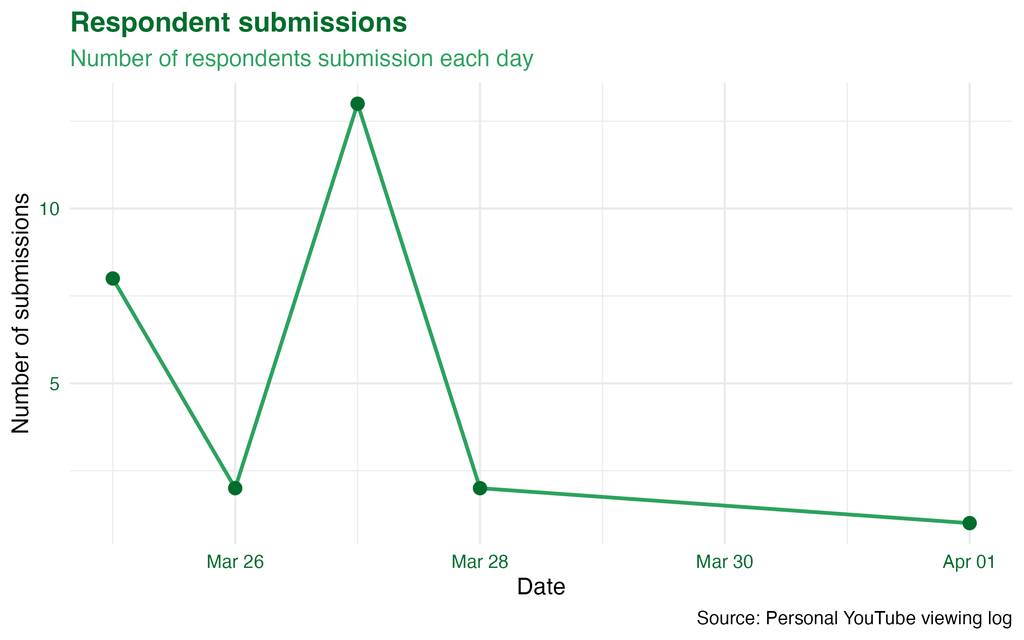

We can see a massive spike of people taking this survey was around the 27th of March, this was when I was actively asking people to participate in my survey, and coming out of my comfort zone to talk to people and interact with them, after gathering a majority of my participants, I asked a few of my friends to take it to give me a solid amount of data to work with, with me testing out my data again for the last time on the 1st of April.

## Where people usually watch their videos

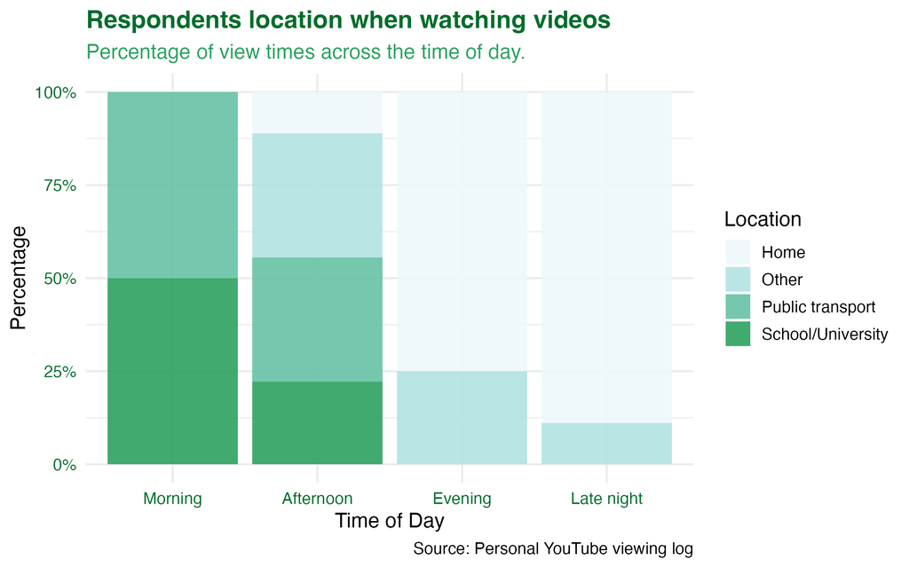